# EDA - 1 krok: Przegląd danych

## Sprawdzam ogólne informacje o danych.

### Poszukuję odpowiedzi na następujące pytania:

- Czego dotyczą dane (jakie są etykiety kolumn)
- Ile jest kategorii do analizy
- Ile jest rekordów (próbek danych)
- Czy są wartości brakujące (jeśli tak, to ile mamy braków)
- Jakiego typu dane są zgromadzone

```
<class 'pandas.core.frame.DataFrame'>
RangeIndex: 150 entries, 0 to 149
Data columns (total 5 columns):
 #   Column                            Non-Null Count  Dtype
---  ------                            --------------  -----
 0   długość kielicha (sepal length)   150 non-null    float64
 1   szerokość kielicha (sepal width)  150 non-null    float64
 2   długość płatka (petal length)     150 non-null    float64
 3   szerokość płatka (petal width)    150 non-null    float64
 4   klasa (class)                     150 non-null    object
dtypes: float64(4), object(1)
memory usage: 6.0+ KB
```

```
długość kielicha (sepal length)     35
szerokość kielicha (sepal width)    23
długość płatka (petal length)       43
szerokość płatka (petal width)      22
klasa (class)                        3
dtype: int64
```

```
array(['Iris-setosa', 'Iris-versicolor', 'Iris-virginica'], dtype=object)
```

|  | długość kielicha (sepal length) | szerokość kielicha (sepal width) | długość płatka (petal length) | szerokość płatka (petal width) | klasa (class) |
| --- | --- | --- | --- | --- | --- |
| 15 | 5.7 | 4.4 | 1.5 | 0.4 | Iris-setosa |
| 82 | 5.8 | 2.7 | 3.9 | 1.2 | Iris-versicolor |
| 17 | 5.1 | 3.5 | 1.4 | 0.3 | Iris-setosa |
| 107 | 7.3 | 2.9 | 6.3 | 1.8 | Iris-virginica |
| 130 | 7.4 | 2.8 | 6.1 | 1.9 | Iris-virginica |
| 124 | 6.7 | 3.3 | 5.7 | 2.1 | Iris-virginica |
| 131 | 7.9 | 3.8 | 6.4 | 2.0 | Iris-virginica |
| 44 | 5.1 | 3.8 | 1.9 | 0.4 | Iris-setosa |
| 96 | 5.7 | 2.9 | 4.2 | 1.3 | Iris-versicolor |
| 132 | 6.4 | 2.8 | 5.6 | 2.2 | Iris-virginica |
| 114 | 5.8 | 2.8 | 5.1 | 2.4 | Iris-virginica |
| 86 | 6.7 | 3.1 | 4.7 | 1.5 | Iris-versicolor |

## Wyświetlenie podstawowych danych statystycznych

|  | długość kielicha (sepal length) | szerokość kielicha (sepal width) | długość płatka (petal length) | szerokość płatka (petal width) |
| --- | --- | --- | --- | --- |
| count | 150.000000 | 150.000000 | 150.000000 | 150.000000 |
| mean | 5.843333 | 3.054000 | 3.758667 | 1.198667 |
| std | 0.828066 | 0.433594 | 1.764420 | 0.763161 |
| min | 4.300000 | 2.000000 | 1.000000 | 0.100000 |
| 25% | 5.100000 | 2.800000 | 1.600000 | 0.300000 |
| 50% | 5.800000 | 3.000000 | 4.350000 | 1.300000 |
| 75% | 6.400000 | 3.300000 | 5.100000 | 1.800000 |
| max | 7.900000 | 4.400000 | 6.900000 | 2.500000 |

## Pogrupowanie wybranych danych statystycznych

|  | klasa (class) | długość kielicha (sepal length) mean | długość kielicha (sepal length) std | długość kielicha (sepal length) min | długość kielicha (sepal length) max | długość kielicha (sepal length) median | długość kielicha (sepal length) count | szerokość kielicha (sepal width) mean | szerokość kielicha (sepal width) std | szerokość kielicha (sepal width) min | szerokość kielicha (sepal width) max | szerokość kielicha (sepal width) median | szerokość kielicha (sepal width) count | długość płatka (petal length) mean | długość płatka (petal length) std | długość płatka (petal length) min | długość płatka (petal length) max | długość płatka (petal length) median | długość płatka (petal length) count | szerokość płatka (petal width) mean | szerokość płatka (petal width) std | szerokość płatka (petal width) min | szerokość płatka (petal width) max | szerokość płatka (petal width) median | szerokość płatka (petal width) count |
| --- | --- | --- | --- | --- | --- | --- | --- | --- | --- | --- | --- | --- | --- | --- | --- | --- | --- | --- | --- | --- | --- | --- | --- | --- | --- |
| 0 | Iris-setosa | 5.006 | 0.352490 | 4.3 | 5.8 | 5.0 | 50 | 3.418 | 0.381024 | 2.3 | 4.4 | 3.4 | 50 | 1.464 | 0.173511 | 1.0 | 1.9 | 1.50 | 50 | 0.244 | 0.107210 | 0.1 | 0.6 | 0.2 | 50 |
| 1 | Iris-versicolor | 5.936 | 0.516171 | 4.9 | 7.0 | 5.9 | 50 | 2.770 | 0.313798 | 2.0 | 3.4 | 2.8 | 50 | 4.260 | 0.469911 | 3.0 | 5.1 | 4.35 | 50 | 1.326 | 0.197753 | 1.0 | 1.8 | 1.3 | 50 |
| 2 | Iris-virginica | 6.588 | 0.635880 | 4.9 | 7.9 | 6.5 | 50 | 2.974 | 0.322497 | 2.2 | 3.8 | 3.0 | 50 | 5.552 | 0.551895 | 4.5 | 6.9 | 5.55 | 50 | 2.026 | 0.274650 | 1.4 | 2.5 | 2.0 | 50 |

## Wstępne informacje (baza) do dalszej analizy:

- Dane dotyczą kwiatów, 3 gatunków Irysów: Iris-setosa, Iris-versicolor, Iris-virginica
- Dane zawierają 5 kategorii do analizy w tym gatunek kwiatów
- Dane zawierają 150 rekordów (każdy wiersz reprezentuje pojedynczy kwiat)
- Zbiór danych zawiera po 50 rekordów dla każdego z 3 gatunków irysów
- W zbiorze danych nie występują puste wartości
- Zbiór danych zawiera łańcuch znaków będący nazwą gatunku oraz liczby typu float charakteryzujące kwiaty.

## Wstępna hipoteza i zdefiniowanie pytań badawczych:

- Jaki zakres rozmiarów przyjmują poszczególne gatunki
- Czy istnieje zależność długości do szerokości kielicha i czy jest to powiązane z gatunkiem
- Czy istnieje zależność długości do szerokości płatka i czy jest to powiązane z gatunkiem
- Czy istniaje zależność rozmiaru kielicha z rozmiarem płatka i czy jest to powiązane z gatunkiem

# EDA - 2 krok: Analiza brakujących wartości

## Jak ustalono w 1 kroku - brak pustych wartości

# EDA - 3 krok: Analiza pojedynczych zmiennych wraz z transformacją danych

- 'długość kielicha (sepal length)'
- 'szerokość kielicha (sepal width)'
- 'długość płatka (petal length)'
- 'szerokość płatka (petal width)'
- 'dł/szer_kielicha' - nowy parametr, współczynnik długości do szerokości kielicha
- 'dł/szer_płatka' - nowy parametr, współczynnik długości do szerokości płatka

## Transformacja danych

- Dodano dwie kolumny:
  - współczynnik długości do szerokości kielicha
  - współczynnik długości do szerokości płatka

|  | długość kielicha (sepal length) | szerokość kielicha (sepal width) | długość płatka (petal length) | szerokość płatka (petal width) | klasa (class) | dł/szer_kielicha | dł/szer_płatka |
| --- | --- | --- | --- | --- | --- | --- | --- |
| 144 | 6.7 | 3.3 | 5.7 | 2.5 | Iris-virginica | 2.030303 | 2.280000 |
| 107 | 7.3 | 2.9 | 6.3 | 1.8 | Iris-virginica | 2.517241 | 3.500000 |
| 36 | 5.5 | 3.5 | 1.3 | 0.2 | Iris-setosa | 1.571429 | 6.500000 |
| 5 | 5.4 | 3.9 | 1.7 | 0.4 | Iris-setosa | 1.384615 | 4.250000 |
| 89 | 5.5 | 2.5 | 4.0 | 1.3 | Iris-versicolor | 2.200000 | 3.076923 |

### Wyświetlenie podstawowych danych statystycznych w rozszerzonej wersji danych o wartości proporcji długości do szerokości kielicha i płatków

|  | długość kielicha (sepal length) | szerokość kielicha (sepal width) | długość płatka (petal length) | szerokość płatka (petal width) | dł/szer_kielicha | dł/szer_płatka |
| --- | --- | --- | --- | --- | --- | --- |
| count | 150.000000 | 150.000000 | 150.000000 | 150.000000 | 150.000000 | 150.000000 |
| mean | 5.843333 | 3.054000 | 3.758667 | 1.198667 | 1.955144 | 4.367166 |
| std | 0.828066 | 0.433594 | 1.764420 | 0.763161 | 0.398697 | 2.651508 |
| min | 4.300000 | 2.000000 | 1.000000 | 0.100000 | 1.268293 | 2.125000 |
| 25% | 5.100000 | 2.800000 | 1.600000 | 0.300000 | 1.551915 | 2.802381 |
| 50% | 5.800000 | 3.000000 | 4.350000 | 1.300000 | 2.032292 | 3.300000 |
| 75% | 6.400000 | 3.300000 | 5.100000 | 1.800000 | 2.224910 | 4.666667 |
| max | 7.900000 | 4.400000 | 6.900000 | 2.500000 | 2.961538 | 15.000000 |

### Pogrupowanie wybranych danych statystycznych w rozszerzonej wersji danych o wartości proporcji długości do szerokości kielicha i płatków

|  | klasa (class) | długość kielicha (sepal length) mean | długość kielicha (sepal length) std | długość kielicha (sepal length) min | długość kielicha (sepal length) max | długość kielicha (sepal length) median | długość kielicha (sepal length) count | szerokość kielicha (sepal width) mean | szerokość kielicha (sepal width) std | szerokość kielicha (sepal width) min | szerokość kielicha (sepal width) max | szerokość kielicha (sepal width) median | szerokość kielicha (sepal width) count | długość płatka (petal length) mean | długość płatka (petal length) std | długość płatka (petal length) min | długość płatka (petal length) max | długość płatka (petal length) median | długość płatka (petal length) count | szerokość płatka (petal width) mean | szerokość płatka (petal width) std | szerokość płatka (petal width) min | szerokość płatka (petal width) max | szerokość płatka (petal width) median | szerokość płatka (petal width) count | dł/szer_kielicha mean | dł/szer_kielicha std | dł/szer_kielicha min | dł/szer_kielicha max | … |
| --- | --- | --- | --- | --- | --- | --- | --- | --- | --- | --- | --- | --- | --- | --- | --- | --- | --- | --- | --- | --- | --- | --- | --- | --- | --- | --- | --- | --- | --- | --- |
| 0 | Iris-setosa | 5.006 | 0.352490 | 4.3 | 5.8 | 5.0 | 50 | 3.418 | 0.381024 | 2.3 | 4.4 | 3.4 | 50 | 1.464 | 0.173511 | 1.0 | 1.9 | 1.50 | 50 | 0.244 | 0.107210 | 0.1 | 0.6 | 0.2 | 50 | 1.474578 | 0.118693 | 1.268293 | 1.956522 | … |
| 1 | Iris-versicolor | 5.936 | 0.516171 | 4.9 | 7.0 | 5.9 | 50 | 2.770 | 0.313798 | 2.0 | 3.4 | 2.8 | 50 | 4.260 | 0.469911 | 3.0 | 5.1 | 4.35 | 50 | 1.326 | 0.197753 | 1.0 | 1.8 | 1.3 | 50 | 2.160402 | 0.228658 | 1.764706 | 2.818182 | … |
| 2 | Iris-virginica | 6.588 | 0.635880 | 4.9 | 7.9 | 6.5 | 50 | 2.974 | 0.322497 | 2.2 | 3.8 | 3.0 | 50 | 5.552 | 0.551895 | 4.5 | 6.9 | 5.55 | 50 | 2.026 | 0.274650 | 1.4 | 2.5 | 2.0 | 50 | 2.230453 | 0.246992 | 1.823529 | 2.961538 | … |

### Histogramy dla Iris-setosa

```
array([[<Axes: title={'center': 'długość kielicha (sepal length)'}>,
        <Axes: title={'center': 'szerokość kielicha (sepal width)'}>],
       [<Axes: title={'center': 'długość płatka (petal length)'}>,
        <Axes: title={'center': 'szerokość płatka (petal width)'}>],
       [<Axes: title={'center': 'dł/szer_kielicha'}>,
        <Axes: title={'center': 'dł/szer_płatka'}>]], dtype=object)
```

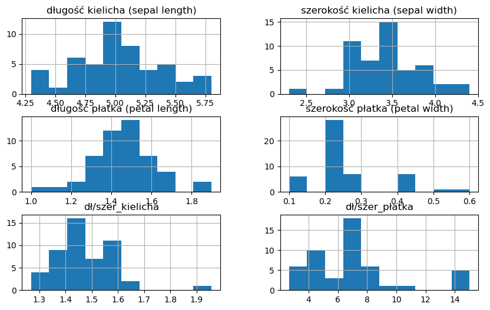

### Histogramy dla Iris_versicolor

```
array([[<Axes: title={'center': 'długość kielicha (sepal length)'}>,
        <Axes: title={'center': 'szerokość kielicha (sepal width)'}>],
       [<Axes: title={'center': 'długość płatka (petal length)'}>,
        <Axes: title={'center': 'szerokość płatka (petal width)'}>],
       [<Axes: title={'center': 'dł/szer_kielicha'}>,
        <Axes: title={'center': 'dł/szer_płatka'}>]], dtype=object)
```

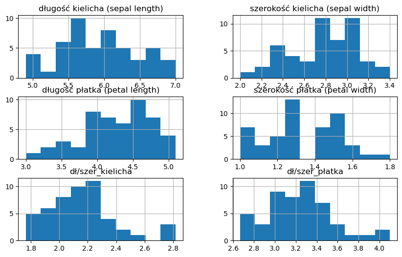

### Histogramy dla Iris_virginica

```
array([[<Axes: title={'center': 'długość kielicha (sepal length)'}>,
        <Axes: title={'center': 'szerokość kielicha (sepal width)'}>],
       [<Axes: title={'center': 'długość płatka (petal length)'}>,
        <Axes: title={'center': 'szerokość płatka (petal width)'}>],
       [<Axes: title={'center': 'dł/szer_kielicha'}>,
        <Axes: title={'center': 'dł/szer_płatka'}>]], dtype=object)
```

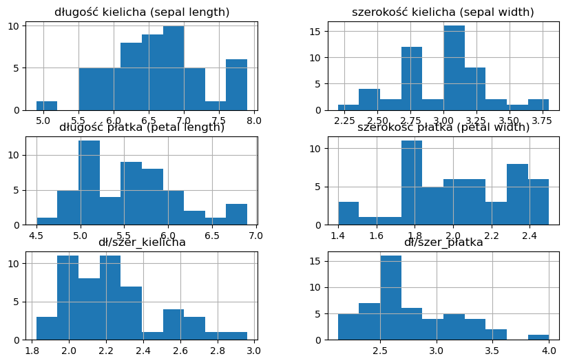

### Wykres liniowy pokazujący proporcje długość do szerokość kielicha i płatków dla Iris-setosa

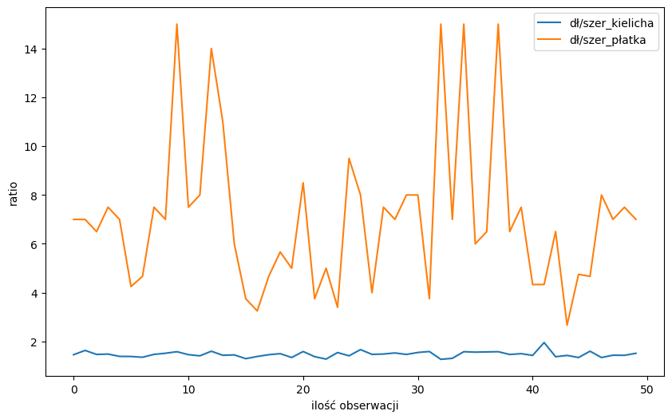

### Wykres liniowy pokazujący proporcje długość do szerokość kielicha i płatków dla Iris-versicolor

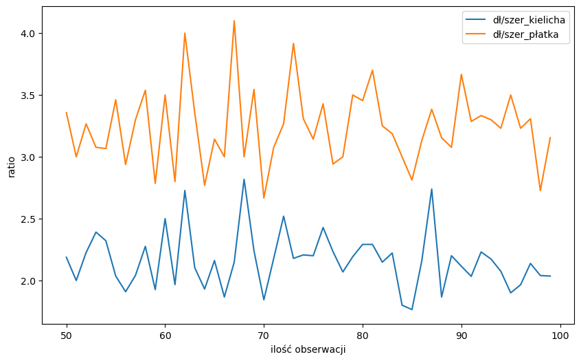

### Wykres liniowy pokazujący proporcje długość do szerokość kielicha i płatków dla Iris-virginica

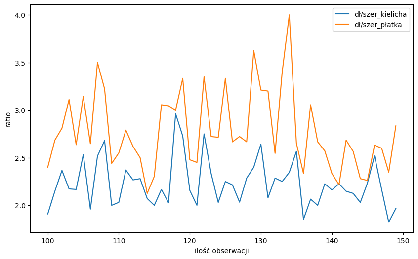

## Uwagi

- Gatunek Iris-setosa wyróżnia się:
  - bardzo małym zróżnicowaniem na co wskazuje niska wartość odchylenia standardowego
  - krótkim (mediana 5cm) i stosunkowo szerokim kielichu (mediana 3,4 cm) na co wskazuje najmniejsza wartość współczynnika długość/szerokość kielicha
  - bardzo drobnymi płatkami (szerokość - mediana 0,2 cm) które wyróżniają się największą smukłością (średnia współczynnika długości do szerokości płatka 7)
  - Zdecydowanie większa smukłość płatków w porównaniu do smukłości kielicha
- Gatunek Iris-virginica chechuje się
  - stosunkowo największym zróżniocowaniem (największe wartości odchylenia standardowego)
  - jest to kwiat o długim i dość smukłym kielichu i dużych płatkach
  - proporcje długości do szerokości kielicha i płatków najbardziej zbliżone do siebie
- Gatunek Iris-versicolor pod względem wielkości i zróżnicowania jest średniakiem bardziej zbliżony do Iris-virginica niż do Iris-setosa

# EDA - 4 krok: Analiza relacji między zmiennymi

## Macierz korelacji

|  | długość kielicha (sepal length) | szerokość kielicha (sepal width) | długość płatka (petal length) | szerokość płatka (petal width) |
| --- | --- | --- | --- | --- |
| długość kielicha (sepal length) | 1.00 | -0.11 | 0.87 | 0.82 |
| szerokość kielicha (sepal width) | -0.11 | 1.00 | -0.42 | -0.36 |
| długość płatka (petal length) | 0.87 | -0.42 | 1.00 | 0.96 |
| szerokość płatka (petal width) | 0.82 | -0.36 | 0.96 | 1.00 |

## Wykresy punktowe dla korelacji pomiędzy parametrami rozmiaru

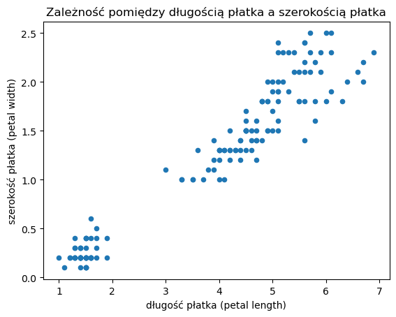

## Najsilniejsza korelacja 0,96 występuje pomiędzy długością a szerokością płatka

- na wykresie wyraźna korelacja dodatnia

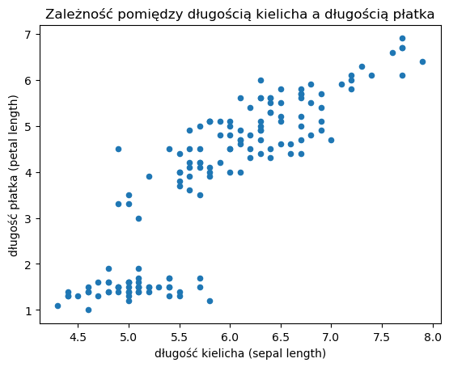

## Druga najsilniejsza korelacja 0,87 występuje pomiędzy długością kielicha a długością płatka

- na wykresie wyraźna korelacja dodatnia

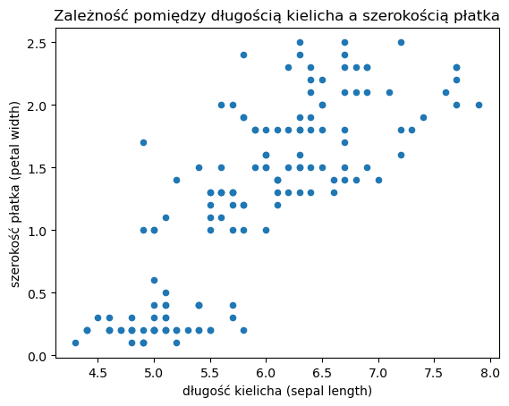

## Trzecia najsilniejsza korelacja 0,82 występuje pomiędzy długością kielicha a szerokością płatka

- na wykresie korelacja dodatnia, choć nie tak wyraźna jak poprzednio

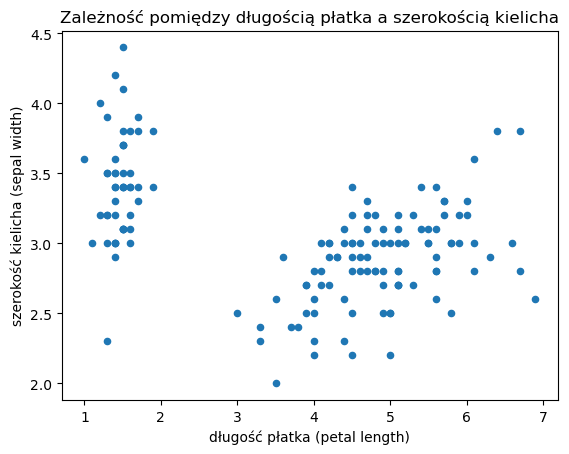

## Pomiędzy długością płatka a szerokością kielicha korelacja -0,42

- na wykresie brak jednoznacznej korelacji

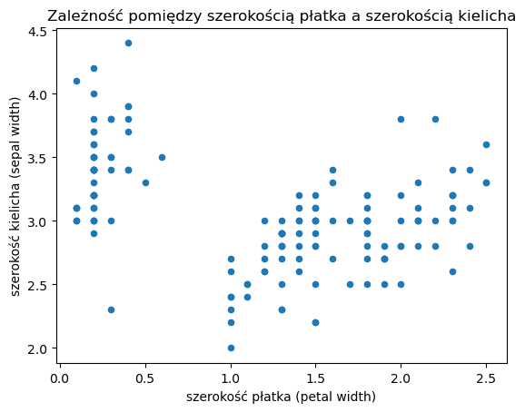

## Pomiędzy szerokością płatka a szerokością kielicha korelacja -0,36

- na wykresie brak jednoznacznej korelacji

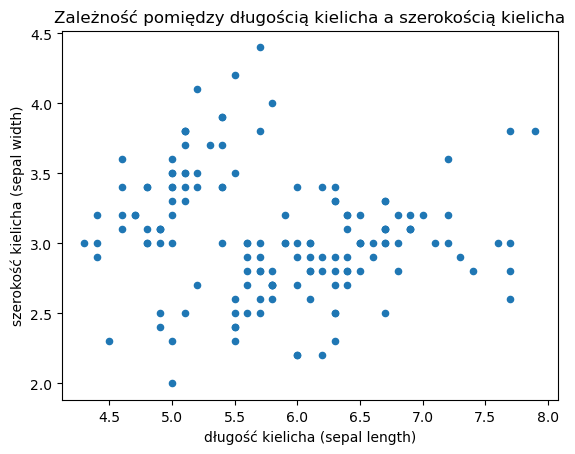

## Pomiędzy długością kielicha a szerokością kielicha korelacja -0,11

- na wykresie brak jednoznacznej korelacji
- analizowane wymiary są najmniej zależne od siebie spośród wszystkich badanych par

# EDA - krok 6: analiza wartości odstających

## Boxploty dla parametrów rozmiaru

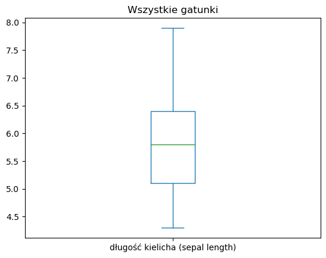

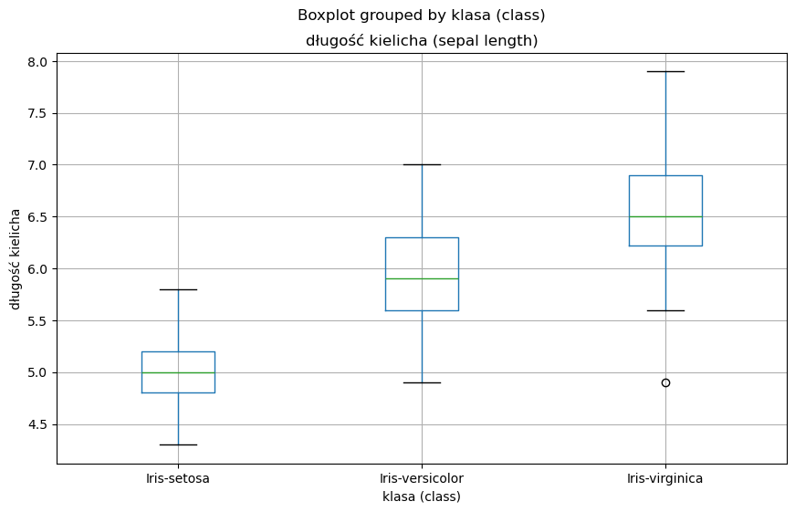

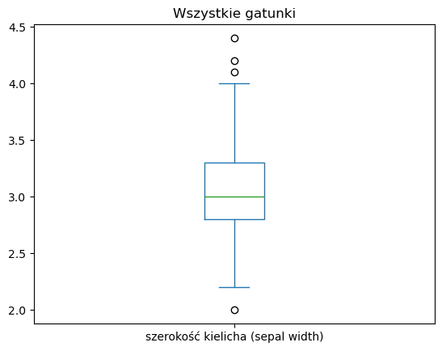

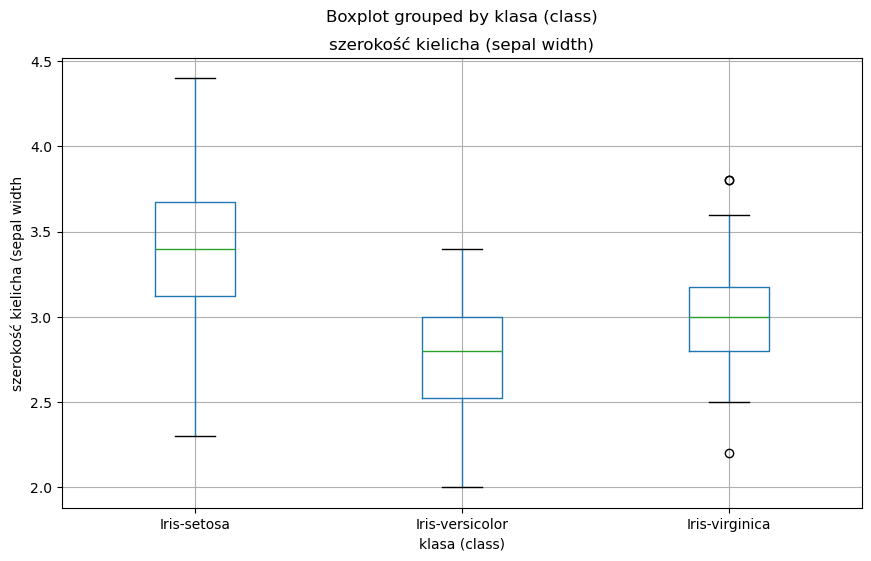

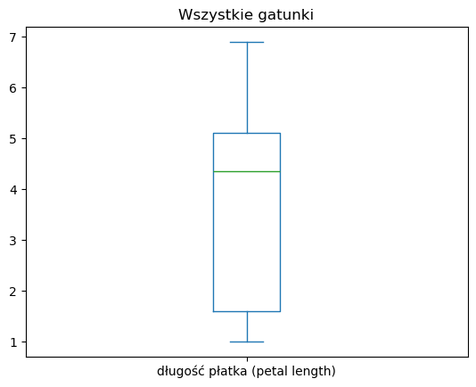

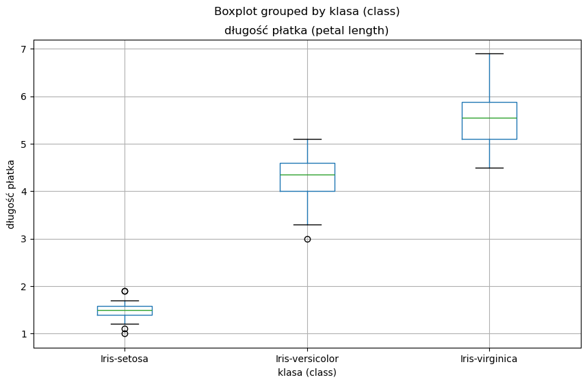

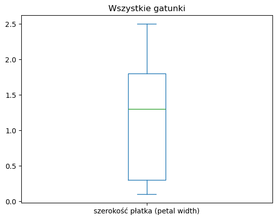

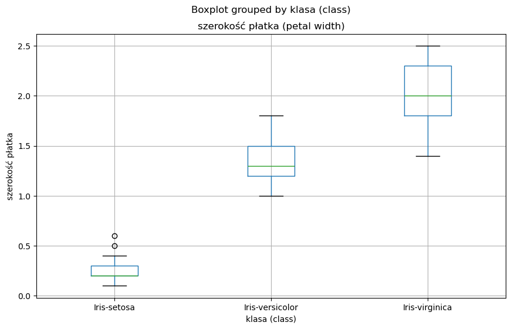

## Wnioski

- Najmniejsze rozproszenie obserwacji występuje dla szerokości kielicha a największe dla długości płatka
- Wyrażna widoczna zależność parametrów wielkości od gatunku irysów
- Potwierdzona mocna tendencja gatunku Iris-setosa do małej różnorodności (wysoka koncentracja obserwacji w małym przedziale) z wyłączeniem szerokości kielicha dla którego rozrzut wyników jest największy
- Najwięcej odstających wartości dla kielicha zaobserwowano dla gatunku Iris-virginica
- Najwięcej odstających wartości dla płatków zaobserwowano dla gatunku Iris-setosa

## Podsumowanie i Wnioski końcowe

- Iris-setosa jest gatunkiem zdecydowanie wyróżniającym się: - rozmiarem (najdrobniejszy kwiat) - proporcjami (najsmuklejsze płatki, najbardziej krępy kielich) - niską różnorodnością
- Iris-virginica jest zdecydowanie największym z pośród badanych 3 gatunków, wyróżnia się: - najbardziej zbliżonymi do siebie proporcjami długości do szerokości kielicha i płatków
- Iris-versicolor pod względem klasyfikacji wielkości zajmuje miejsce pośrednie, choć wyróżnia się: - najmniejszą szerokością kielicha
- Bazując na całym zbiorze danych najmniejsza korelacja występuje pomiędzy długością a szerokością kielicha
- Istnieje bardzo mocna dodatnia zależność długości do szerokości płatka jak również widoczna odrębność gatunków
- Istnieje wyrażna dodatnia zależność długości płatka i długości kielicha oraz szerokości płatka i długości kielicha
- Długość i szerokość kielicha są przypadkowe - nie stwierdzono korelacji